# Áreas Protegidas

Publicación del Informe de visitas en Áreas Protegidas en Argentina, que recopila información de visitas en Parques Nacionales y Provinciales del país.

# Presentación

Con el propósito de ampliar el trabajo realizado hasta el momento en colaboración con la Dirección de Mercadeo de la Dirección Nacional de Uso Público, dependiente de la Administración de Parques Nacionales, la Dirección Nacional de Mercados y Estadística (DNMyE) incluye datos sobre visitas en áreas protegidas provinciales en el informe de visitas en Parques Nacionales que se venía publicando.

A partir de febrero 2023, en el informe disponible en el [SINTA](https://www.yvera.tur.ar/sinta/informe/info/areas-protegidas), se agrega información histórica de visitas por condición de residencia en las Áreas Protegidas Naturales del Chubut y las visitas del Parque Provincial Ischigualasto, en la provincia de San Juan, ampliando la información de visitas a destinos vinculados al Turismo de Naturaleza en el país.

En el siguiente gráfico se puede observar la evolución histórica del total de las visitas del Sitio de Patrimonio de la Humanidad compuesto por el Parque Provincial Ischigualasto y el Parque Nacional Talampaya.

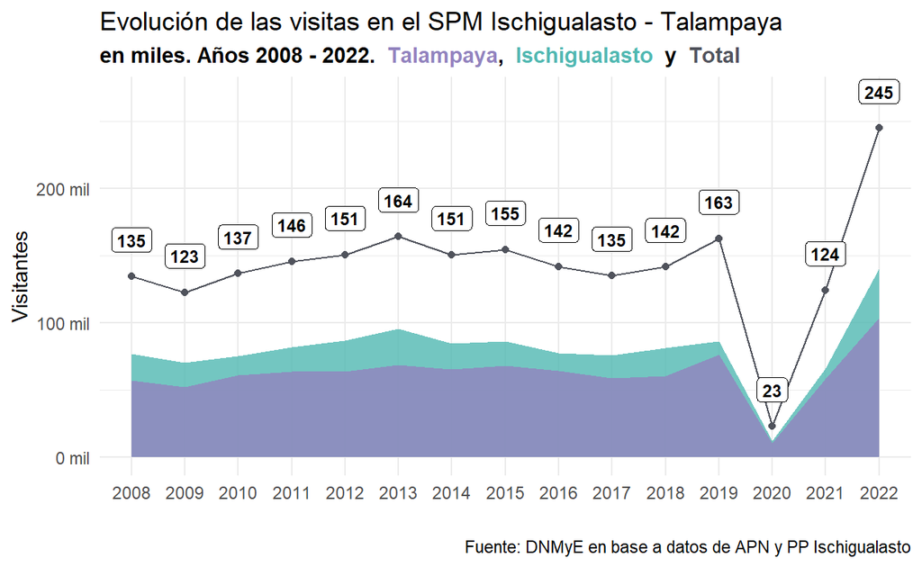

Asimismo, se observa la estacionalidad de las visitas en ambas áreas protegidas en el año 2022, con picos de afluencia durante las vacaciones de invierno, y en los meses de abril y septiembre - octubre.

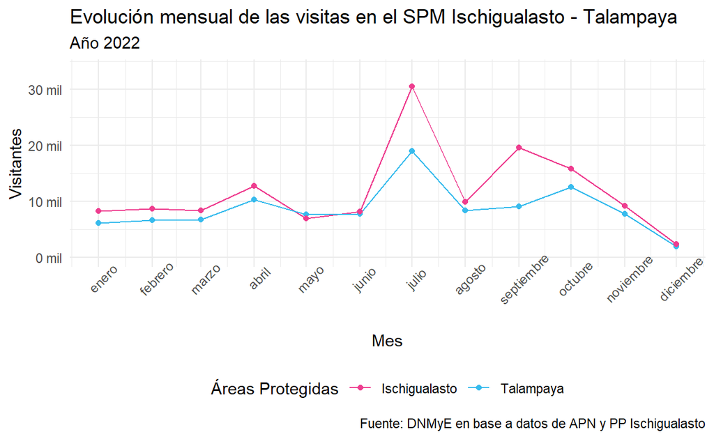

En el caso de la provincia del Chubut, se puede ver la evolución histórica de las visitas en tanto en áreas protegidas nacionales como provinciales, y observar la importancia del Área Natural Protegida Península Valdés dentro de la provincia.

*Nota: a partir del 2014 el PN Lago Puelo registró visitantes en forma mensual, mientras que del 2008 al 2013 se registraban los visitantes sólo los meses de temporada alta (enero a Semana Santa y diciembre).*

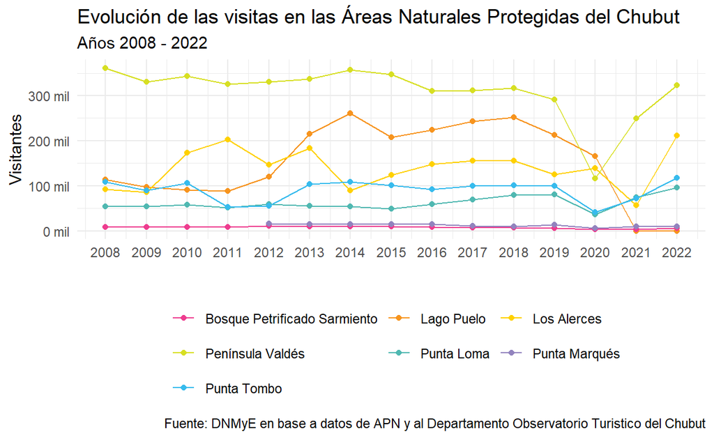

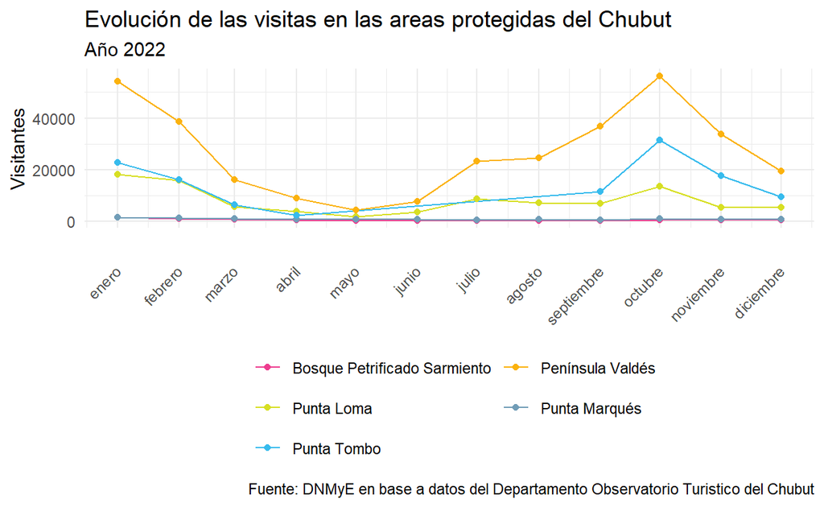